# Project Statistical Results

Malik Salim

2022-05-10

Question: What is the relationship between diabetes status and BMI, age, and gender in Americans during the years 2009–12?

Dependent variable: Diabetes status. This variable will be coded as 1 for people who have been diagnosed with diabetes and 0 for people who have not been diagnosed.

Independent variables: BMI, age, and gender.

```r
library(NHANES)
library(ggplot2)
```

```r
data(NHANES)
df1 <- NHANES
```

```r
df1 <- df1[c("Diabetes","Gender","Age","BMI")]
```

```r
summary(df1)
```

```
##  Diabetes       Gender          Age             BMI
##  No  :9098   female:5020   Min.   : 0.00   Min.   :12.88
##  Yes : 760   male  :4980   1st Qu.:17.00   1st Qu.:21.58
##  NA's: 142                 Median :36.00   Median :25.98
##                            Mean   :36.74   Mean   :26.66
##                            3rd Qu.:54.00   3rd Qu.:30.89
##                            Max.   :80.00   Max.   :81.25
##                                            NA's   :366
```

#Removing observations with missing data

```r
df1 <- na.omit(df1)
```

```r
dim(df1)
```

```
## [1] 9629    4
```

My next step is to prepare any variables that are not already ready for analysis. So, I am converting categorical variables—diabetes status, and gender into dummy variables.

```r
library(fastDummies)
df1 <- dummy_cols(df1,select_columns = c("Diabetes","Gender"))
```

#List of variables in our datset

```r
names(df1)
```

```
## [1] "Diabetes"      "Gender"        "Age"           "BMI"
## [5] "Diabetes_No"   "Diabetes_Yes"  "Gender_female" "Gender_male"
```

#Visualization of our Data

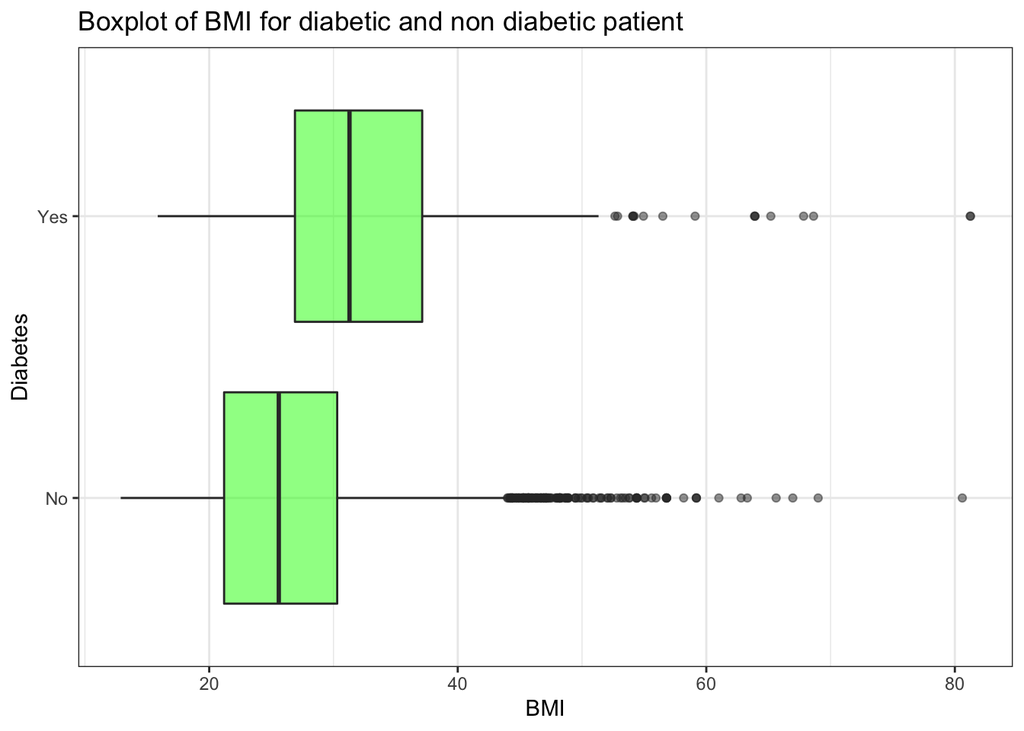

```r
ggplot(df1, aes(x = Diabetes, y = BMI))+
  geom_boxplot(fill = 'green', alpha = 0.5)+
  coord_flip()+
  labs(title = "Boxplot of BMI for diabetic and non diabetic patient")+
  theme_bw()
```

Side-by-side boxplot shows that the BMI is slightly high for diabetic individuals. In addition to that,there are more outliners in BMI for non-diabetic patients.

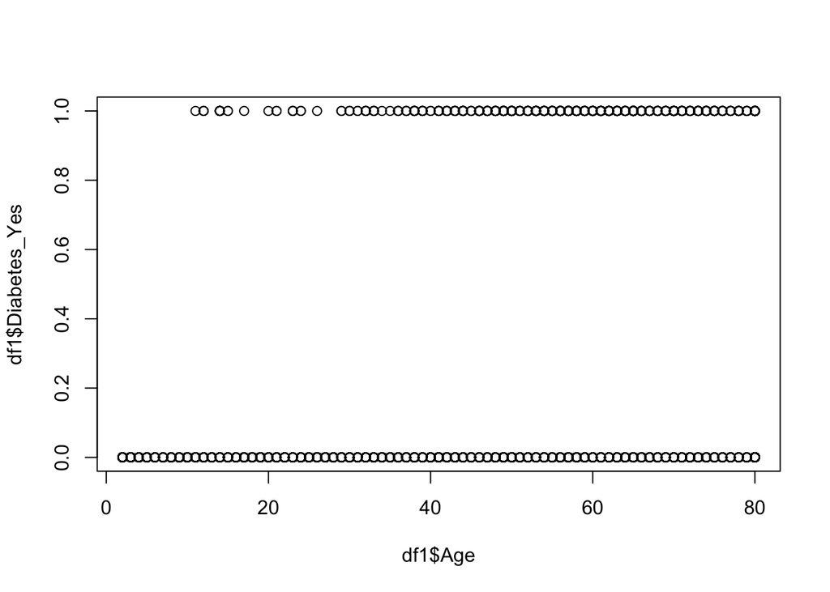

```r
plot(df1$Age, df1$Diabetes_Yes)
```

In the plot above, it is still pretty hard to visually determine if there is any relationship between diabetes status and age. However, it appears that all of the people who have diabetes are older than some people who do not have diabetes. More specifically: people between ages 0 and 30 years old visually appear to be more likely to not have diabetes than to have it. And then for ages above 30 years old, we cannot really tell from this scatterplot.

We can also make some two-way tables to explore descriptive relationships between diabetes status and our categorical independent variables

# We begin with a two-way table of diabetes status and gender, below:

```r
with(df1, table(Diabetes_Yes, Gender_female))
```

```
##             Gender_female
## Diabetes_Yes    0    1
##            0 4395 4485
##            1  395  354
```

# Visualize logistic regression

```r
logit.sim <- glm(Diabetes_Yes ~ BMI, data = df1, family = "binomial")
```

```r
BMIrange = seq(min(df1$BMI),max(df1$BMI),0.01)
```

```r
logit.sim.prob <- predict(logit.sim, list(BMI = BMIrange), type = "response")
```

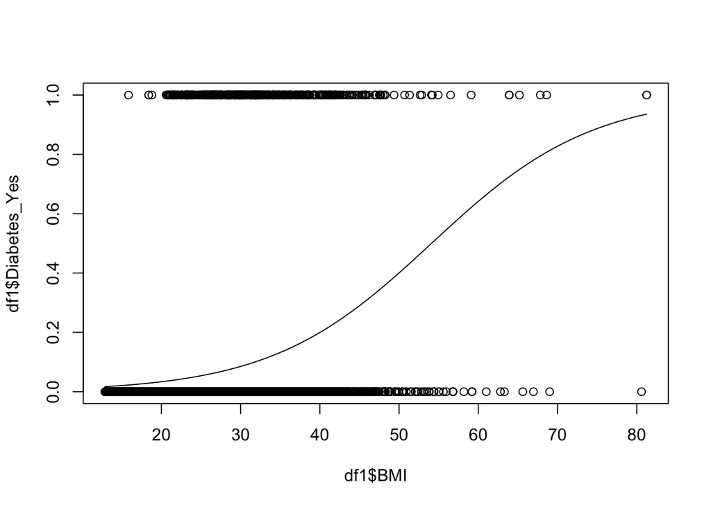

```r
plot(df1$BMI, df1$Diabetes_Yes)
lines(BMIrange, logit.sim.prob)
```

Somebody who has a BMI of 10 is predicted to have diabetes with a probability that is just over 0. In other words, the regression model is telling us that somebody with a BMI of 10 has a very low chance of having diabetes. Somebody who has a BMI of 40 is predicted to have diabetes with a probability of approximately 0.2. In other words, the regression model is telling us that somebody with a BMI of 40 has approximately a 20% chance of having diabetes. Somebody who has a BMI of 70 is predicted to have diabetes with a probability of approximately 0.8. In other words, the regression model is telling us that somebody with a BMI of 70 has approximately an 80% chance of having diabetes. As BMI increases, the probability or likelihood of having diabetes also increases.

#chi-square analysis

H0 (Null Hypothesis) : There is no relationship between BMI and Age, independent variables. H1 (Alternate Hypothesis) : There is a relationship between BMI and Age , dependent variables.

```r
chisquare_test <- chisq.test(table(df1$BMI, df1$Age))
chisquare_test
```

```
##
##  Pearson's Chi-squared test
##
## data:  table(df1$BMI, df1$Age)
## X-squared = 255021, df = 161616, p-value < 2.2e-16
```

When examining the association betwen BMI and Age, a chi-square test revealed that there is a strong relationship between BMI and Age (X-squared = 255021, df = 161616, p<0.001).

# Interpreting multiple logistic regression

```r
logit <- glm(Diabetes_Yes ~ BMI + Age + Gender_female, data = df1, family = "binomial")
```

```r
summary(logit)
```

```
##
## Call:
## glm(formula = Diabetes_Yes ~ BMI + Age + Gender_female, family = "binomial",
##     data = df1)
##
## Deviance Residuals:
##     Min       1Q   Median       3Q      Max
## -1.8752  -0.4122  -0.2288  -0.0999   3.3427
##
## Coefficients:
##                Estimate Std. Error z value Pr(>|z|)
## (Intercept)   -8.020370   0.246583 -32.526  < 2e-16 ***
## BMI            0.096478   0.005595  17.243  < 2e-16 ***
## Age            0.058228   0.002519  23.111  < 2e-16 ***
## Gender_female -0.364530   0.083312  -4.375 1.21e-05 ***
## ---
## Signif. codes:  0 '***' 0.001 '**' 0.01 '*' 0.05 '.' 0.1 ' ' 1
##
## (Dispersion parameter for binomial family taken to be 1)
##
##     Null deviance: 5263.8  on 9628  degrees of freedom
## Residual deviance: 4126.7  on 9625  degrees of freedom
## AIC: 4134.7
##
## Number of Fisher Scoring iterations: 7
```

Above, for every one year increase in the independent variable Age, the log odds of the dependent variable Diabetes_Yes are predicted to increase by 0.058, controlling for all other independent variables

If we keep our results in log odds form, they are not easy to interpret, as you saw above.

We can get more clear results the summ() function from the jtools package but before we do that, we can get 95% confidence intervals for these odds ratios to help make inferences.

```r
exp(cbind(OR = coef(logit), confint(logit)))
```

```
##                         OR        2.5 %       97.5 %
## (Intercept)   0.0003286983 0.0002010268 0.0005286213
## BMI           1.1012858871 1.0893331392 1.1134994788
## Age           1.0599563635 1.0547987237 1.0652707035
## Gender_female 0.6945231341 0.5896276380 0.8174376091
```

```r
library(jtools)

summ(logit, exp = TRUE, confint = TRUE)
```

```
## MODEL INFO:
## Observations: 9629
## Dependent Variable: Diabetes_Yes
## Type: Generalized linear model
##   Family: binomial
##   Link function: logit
##
## MODEL FIT:
## χ²(3) = 1137.06, p = 0.00
## Pseudo-R² (Cragg-Uhler) = 0.26
## Pseudo-R² (McFadden) = 0.22
## AIC = 4134.69, BIC = 4163.38
##
## Standard errors: MLE
## --------------------------------------------------------------
##                       exp(Est.)   2.5%   97.5%   z val.      p
## ------------------- ----------- ------ ------- -------- ------
## (Intercept)                0.00   0.00    0.00   -32.53   0.00
## BMI                        1.10   1.09    1.11    17.24   0.00
## Age                        1.06   1.05    1.07    23.11   0.00
## Gender_female              0.69   0.59    0.82    -4.38   0.00
## --------------------------------------------------------------
```

```r
 summ(logit, exp = TRUE, confint = TRUE)
```

```
## MODEL INFO:
## Observations: 9629
## Dependent Variable: Diabetes_Yes
## Type: Generalized linear model
##   Family: binomial
##   Link function: logit
##
## MODEL FIT:
## χ²(3) = 1137.06, p = 0.00
## Pseudo-R² (Cragg-Uhler) = 0.26
## Pseudo-R² (McFadden) = 0.22
## AIC = 4134.69, BIC = 4163.38
##
## Standard errors: MLE
## --------------------------------------------------------------
##                       exp(Est.)   2.5%   97.5%   z val.      p
## ------------------- ----------- ------ ------- -------- ------
## (Intercept)                0.00   0.00    0.00   -32.53   0.00
## BMI                        1.10   1.09    1.11    17.24   0.00
## Age                        1.06   1.05    1.07    23.11   0.00
## Gender_female              0.69   0.59    0.82    -4.38   0.00
## --------------------------------------------------------------
```

BMI – For every one unit increase in BMI, the odds of diabetes are predicted to change on average by 1.10 times, controlling for all other independent variables. In other words, for every one-unit increase in BMI, there is almost 10% average increase in the odds of having diabetes, controlling for all other independent variables

Age – For every one-unit increase in Age, the odds of diabetes are predicted to change on average by 1.06 times, controlling for all other independent variables. In other words, for every one-unit increase in Age, there is a almost 6% average increase in the odds of having diabetes, controlling for all other independent variables.

Since the p-value for BMI is very low— less than (<0.001) —we have a lot of support in favor of the alternate hypothesis and we can reject the null hypothesis. This conclusion is also supported by our 95% confidence interval for BMI, which is entirely above 1.